# I can find ‘Nuclear Inssa!’(나는 핵인싸를 찾을 수 있다!)

DataMarketingStudy

2019-11-30

## Step 1. 데이터 구조 확인 / 데이터프레임 형식 변환

- 첫번째 단계는 바로 데이터 구조를 파악하고, 데이터프레임 형식을 네트워크 그래프 형식으로 변환합니다.

```r
library(igraph) # 네트워크 그래프는 igraph 패키지를 이용합니다.
inssalist<-read.csv("inssalist.csv") #데이터 불러오기
str(inssalist) #데이터 구조 파악
```

```
## 'data.frame':    18 obs. of  3 variables:
##  $ X   : int  1 2 3 4 5 6 7 8 9 10 ...
##  $ from: Factor w/ 8 levels "고병주","김만식",..: 2 2 2 2 2 3 3 3 3 7 ...
##  $ to  : Factor w/ 7 levels "고병주","김만식",..: 3 6 1 5 7 6 1 5 7 1 ...
```

```r
inssalist <- inssalist[,-1] # 필요없는 첫번째 컬럼 제거
head(inssalist) # 일부 데이터 확인
```

```
##     from       to
## 1 김만식   김화자
## 2 김만식 정에스더
## 3 김만식   고병주
## 4 김만식   정겨원
## 5 김만식 제임스박
## 6 김화자 정에스더
```

- 데이터프레임을 네트워크 그래프로 표현할 수 있게 형식을 변환해줍니다.
- 네트워크 그래프 형식으로 변환된 데이터 프레임을 Head 함수를 이용하여 살펴보니,  
  두 사람 간 관계가 있을 경우 ‘1’로 없을 경우’.’으로 벡터값이 나오는 것을 확인할 수 있습니다.

```r
dfinssa<-graph.data.frame(inssalist, directed = FALSE) #네트워크 그래프 형식으로 변환
dfinssa
```

```
## IGRAPH 402025b UN-- 9 18 --
## + attr: name (v/c)
## + edges from 402025b (vertex names):
##  [1] 김만식  --김화자   김만식  --정에스더 김만식  --고병주
##  [4] 김만식  --정겨원   김만식  --제임스박 김화자  --정에스더
##  [7] 김화자  --고병주   김화자  --정겨원   김화자  --제임스박
## [10] 정에스더--고병주   고병주  --정겨원   고병주  --왕수정
## [13] 정겨원  --제임스박 정에스더--제임스박 김만식  --장발장
## [16] 정에스더--손승봄   김화자  --손승봄   고병주  --손승봄
```

```r
head(dfinssa)
```

```
## 6 x 9 sparse Matrix of class "dgCMatrix"
##          김만식 김화자 정에스더 고병주 정겨원 제임스박 장발장 손승봄
## 김만식        .      1        1      1      1        1      1      .
## 김화자        1      .        1      1      1        1      .      1
## 정에스더      1      1        .      1      .        1      .      1
## 고병주        1      1        1      .      1        .      .      1
## 정겨원        1      1        .      1      .        1      .      .
## 제임스박      1      1        1      .      1        .      .      .
##          왕수정
## 김만식        .
## 김화자        .
## 정에스더      .
## 고병주        1
## 정겨원        .
## 제임스박      .
```

## 네트워크 그래프 그리기

- 이제 네트워크 그래프를 그려보도록 하겠습니다.

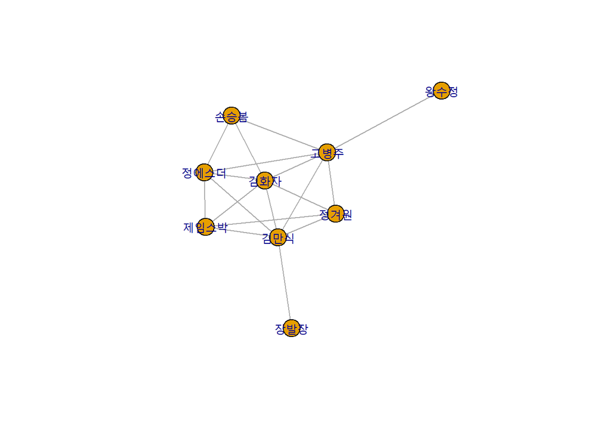

```r
set.seed(100)
plot(dfinssa)
```

- 국방대 경영학과 19학번의 인스타 팔로 관계를 보여주는 네트워크 그래프가 생성되었습니다.
- 그래프의 중앙에 위치하고, 연결이 많을수록 핵인싸라는 것을 알 수 있습니다.  
  그러나 이 그래프는 모든 원의 크기가 동일하게 되어 있어, 한눈에 그래프가 보이도록 조절하도록 하겠습니다.

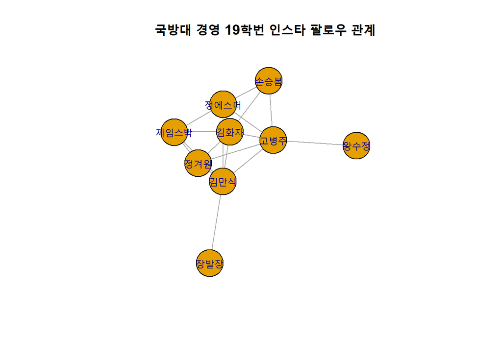

```r
set.seed(123)
plot(dfinssa, vertex.size = 30, main = "국방대 경영 19학번 인스타 팔로우 관계")
```

- 원(노드)의 크기를 조금 키우니, 보기는 좋아진 것 같습니다.  
  하지만 아쉽게도 노드의 크기가 같으니, 노드 간의 중요도 차이를 파악하기가 어려운 것 같습니다.  
  그래서 중요도를 기준으로 노드의 크기를 다르게 표현해보도록 하겠습니다.
- 노드의 중요도를 판단하는 방법은 여러 가지가 있는데, `연결 중심성`, `근접 중심성`, `페이지랭크` 방법등이 있습니다.  
  이 예제에서는 노드에 연결된 edge(선) 수에 따라 중요도를 파악하는 `연결 중심성` 방법을 사용하도록 하겠습니다.

```r
degree(dfinssa) # 각 노드에 연결된 edge 수를 파악하는 함수
```

```
##   김만식   김화자 정에스더   고병주   정겨원 제임스박   장발장   손승봄
##        6        6        5        6        4        4        1        3
##   왕수정
##        1
```

- 각 노드별 edge 수를 파악하고 난 후, 각 edge 수를 기준으로 다시 네트워크 그래프를 그려보도록 하겠습니다.

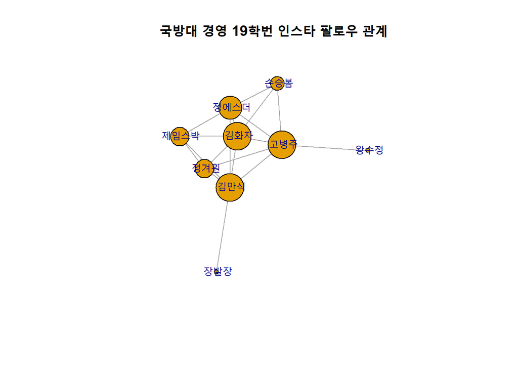

```r
set.seed(123)
plot(dfinssa, vertex.size = degree(dfinssa)*5,
     vertex.label.dist =0.3,
     main="국방대 경영 19학번 인스타 팔로우 관계")
```